# LHS Case Study: Joint Credible Regions by Sampling Design

## Setup

```r
renv::load("/Users/max/r_package_development/bayes2stage")
```

```
- The project is out-of-sync -- use `renv::status()` for details.
```

```r
library(ggplot2)
library(patchwork)
theme_set(cowplot::theme_cowplot(font_size = 12, font_family = "Source Sans Pro"))

SCRIPT_DIR <- "."
source("lhs_config.R")
fs::dir_create("figures")
```

## Load Data

```r
df <- load_lhs_data()
N_SUBJECTS <- length(unique(df$id))
N_SAMPLED <- as.integer(SAMPLING_FRACTION * N_SUBJECTS)
```

The LHS cohort has **2562 subjects** with longitudinal FVC measurements and a polygenic risk score (PRS) computed from 43 SNPs. Each two-stage design selects **640 subjects (25%)** for PRS measurement; the Bayesian model imputes PRS for the remaining 75%.

## Load Pre-Computed Posterior Draws

Results are pre-computed by `fit_design.R` via `fit_all_designs.sh`. Each design writes posterior draws to `cr_results/<design>.parquet`.

```r
result_files <- fs::dir_ls("cr_results", glob = "*.parquet")
cli::cli_alert_info("Found {length(result_files)} result files")
```

```
ℹ Found 8 result files
```

```r
draws_df <- purrr::map(result_files, arrow::read_parquet) |>
    dplyr::bind_rows()

DESIGN_LABELS <- c(
    full          = "Full data",
    srs           = "SRS",
    ods_intercept = "ODS (intercept)",
    ods_slope     = "ODS (slope)",
    ods_ellipse   = "ODS (ellipse)",
    bds_intercept = "BDS (intercept)",
    bds_slope     = "BDS (slope)",
    bds_ellipse   = "BDS (ellipse)"
)

DESIGN_ORDER <- c(
    "Full data", "SRS",
    "ODS (intercept)", "ODS (slope)", "ODS (ellipse)",
    "BDS (intercept)", "BDS (slope)", "BDS (ellipse)"
)

draws_df <- draws_df |>
    dplyr::mutate(design_label = factor(DESIGN_LABELS[design], levels = DESIGN_ORDER))

cli::cli_alert_success(
    "Loaded {nrow(draws_df)} total draws across {length(unique(draws_df$design))} designs"
)
```

```
✔ Loaded 8000 total draws across 8 designs
```

## Joint Credible Regions

```r
DESIGN_COLORS <- c(
    "Full data"        = "black",
    "SRS"              = "grey50",
    "ODS (intercept)"  = "#1b9e77",
    "ODS (slope)"      = "#7570b3",
    "ODS (ellipse)"    = "#e7298a",
    "BDS (intercept)"  = "#d95f02",
    "BDS (slope)"      = "#66a61e",
    "BDS (ellipse)"    = "#e6ab02"
)
```

### All designs

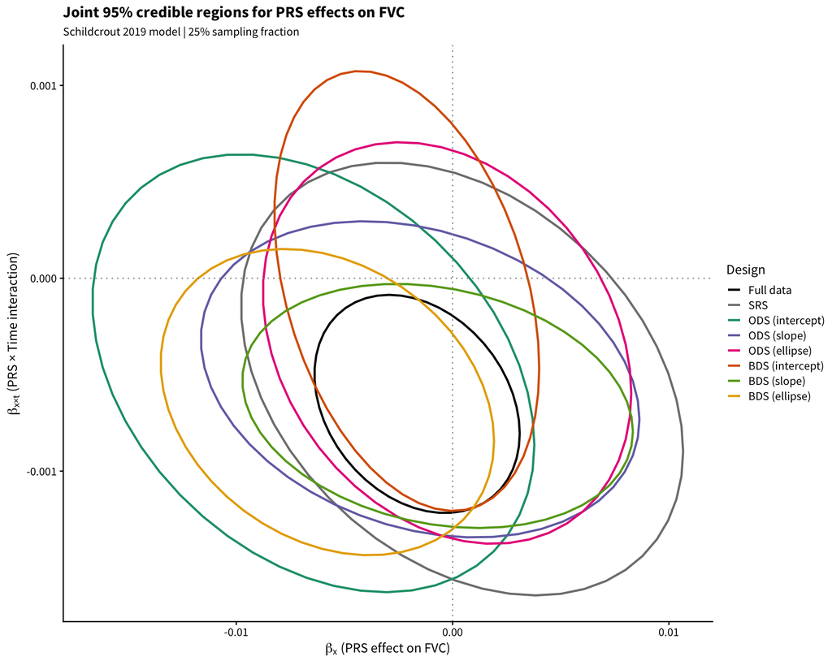

Figure 1

```r
p_all <- draws_df |>
    ggplot(aes(x = beta_x, y = beta_xt, color = design_label)) +
    stat_ellipse(level = 0.95, linewidth = 0.9) +
    geom_hline(yintercept = 0, linetype = "dotted", color = "grey60") +
    geom_vline(xintercept = 0, linetype = "dotted", color = "grey60") +
    scale_color_manual(values = DESIGN_COLORS) +
    labs(
        title = "Joint 95% credible regions for PRS effects on FVC",
        subtitle = "Schildcrout 2019 model | 25% sampling fraction",
        x = expression(beta[x] ~ "(PRS effect on FVC)"),
        y = expression(beta["x\u00d7t"] ~ "(PRS \u00d7 Time interaction)"),
        color = "Design"
    )

p_all

ggsave("figures/credible_regions_all.png", p_all,
    device = ragg::agg_png, bg = "white", dpi = 500,
    width = 10, height = 8, units = "in")
```

### ODS designs vs reference

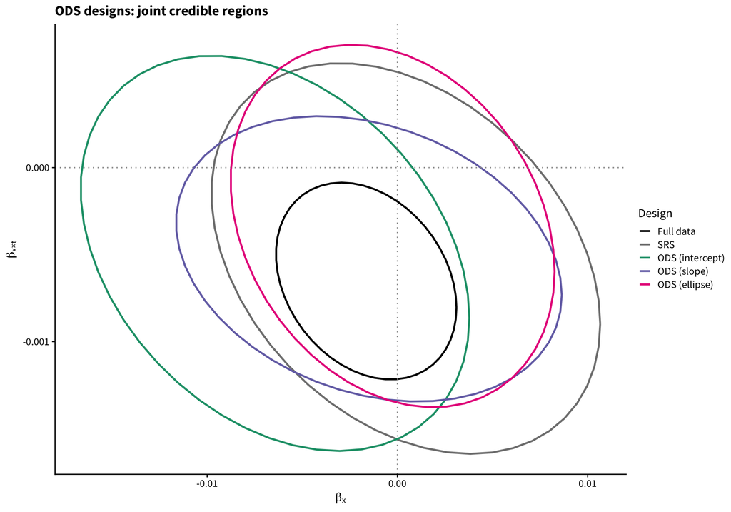

Figure 2

```r
ods_designs <- c("Full data", "SRS",
                 "ODS (intercept)", "ODS (slope)", "ODS (ellipse)")

p_ods <- draws_df |>
    dplyr::filter(design_label %in% ods_designs) |>
    ggplot(aes(x = beta_x, y = beta_xt, color = design_label)) +
    stat_ellipse(level = 0.95, linewidth = 0.9) +
    geom_hline(yintercept = 0, linetype = "dotted", color = "grey60") +
    geom_vline(xintercept = 0, linetype = "dotted", color = "grey60") +
    scale_color_manual(values = DESIGN_COLORS[ods_designs]) +
    labs(
        title = "ODS designs: joint credible regions",
        x = expression(beta[x]),
        y = expression(beta["x\u00d7t"]),
        color = "Design"
    )

p_ods

ggsave("figures/credible_regions_ods.png", p_ods,
    device = ragg::agg_png, bg = "white", dpi = 500,
    width = 10, height = 7, units = "in")
```

### BDS designs vs reference

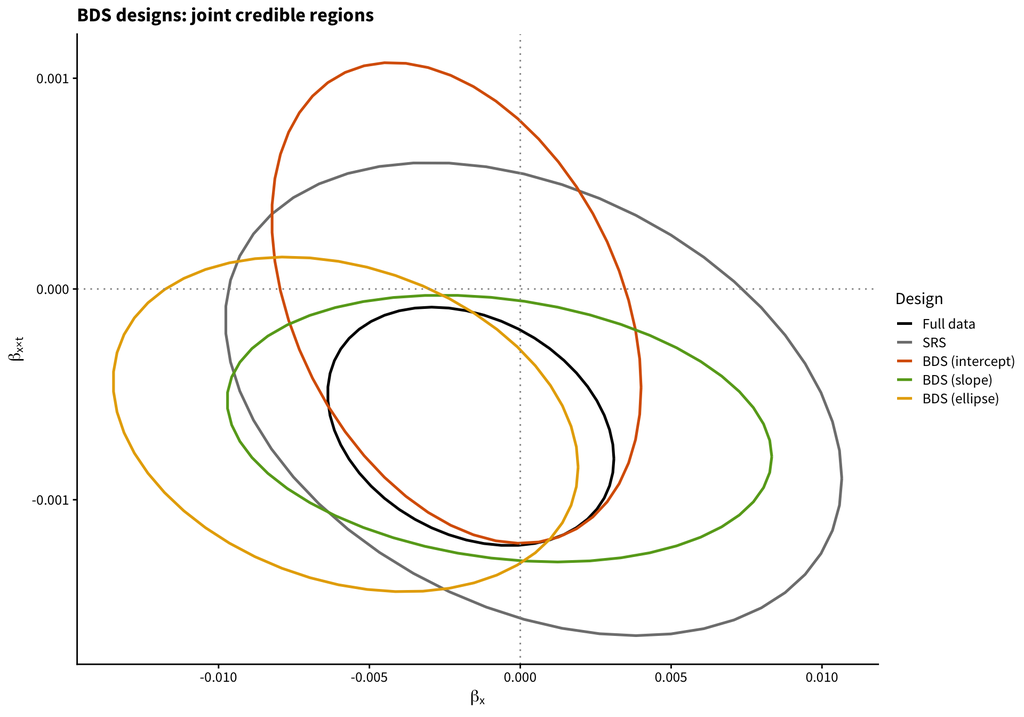

Figure 3

```r
bds_designs <- c("Full data", "SRS",
                 "BDS (intercept)", "BDS (slope)", "BDS (ellipse)")

p_bds <- draws_df |>
    dplyr::filter(design_label %in% bds_designs) |>
    ggplot(aes(x = beta_x, y = beta_xt, color = design_label)) +
    stat_ellipse(level = 0.95, linewidth = 0.9) +
    geom_hline(yintercept = 0, linetype = "dotted", color = "grey60") +
    geom_vline(xintercept = 0, linetype = "dotted", color = "grey60") +
    scale_color_manual(values = DESIGN_COLORS[bds_designs]) +
    labs(
        title = "BDS designs: joint credible regions",
        x = expression(beta[x]),
        y = expression(beta["x\u00d7t"]),
        color = "Design"
    )

p_bds

ggsave("figures/credible_regions_bds.png", p_bds,
    device = ragg::agg_png, bg = "white", dpi = 500,
    width = 10, height = 7, units = "in")
```

### Faceted by design

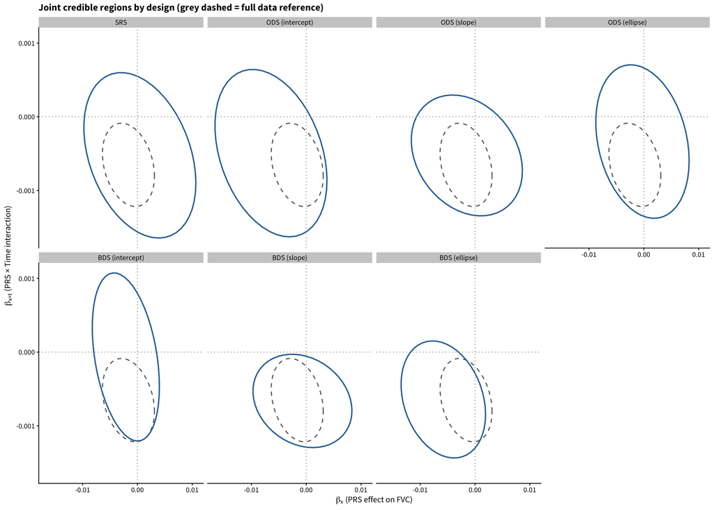

Figure 4

```r
full_draws <- draws_df |>
    dplyr::filter(design == "full") |>
    dplyr::select(-design, -design_label)

p_facet <- draws_df |>
    dplyr::filter(design != "full") |>
    ggplot(aes(x = beta_x, y = beta_xt)) +
    stat_ellipse(
        data = full_draws, aes(x = beta_x, y = beta_xt),
        level = 0.95, linewidth = 0.7, color = "grey40", linetype = "dashed"
    ) +
    stat_ellipse(level = 0.95, color = "#3574a7", linewidth = 0.9) +
    geom_hline(yintercept = 0, linetype = "dotted", color = "grey60") +
    geom_vline(xintercept = 0, linetype = "dotted", color = "grey60") +
    facet_wrap(~ design_label, ncol = 4) +
    labs(
        title = "Joint credible regions by design (grey dashed = full data reference)",
        x = expression(beta[x] ~ "(PRS effect on FVC)"),
        y = expression(beta["x\u00d7t"] ~ "(PRS \u00d7 Time interaction)")
    )

p_facet

ggsave("figures/credible_regions_faceted.png", p_facet,
    device = ragg::agg_png, bg = "white", dpi = 500,
    width = 14, height = 10, units = "in")
```

## Bayesian Probability Statements

```r
prob_df <- draws_df |>
    dplyr::summarize(
        p_bx_pos   = mean(beta_x > 0),
        p_bxt_neg  = mean(beta_xt < 0),
        p_joint    = mean(beta_x > 0 & beta_xt < 0),
        median_bx  = median(beta_x),
        median_bxt = median(beta_xt),
        q2_5_bx    = quantile(beta_x, 0.025),
        q97_5_bx   = quantile(beta_x, 0.975),
        q2_5_bxt   = quantile(beta_xt, 0.025),
        q97_5_bxt  = quantile(beta_xt, 0.975),
        .by = design_label
    )
```

### Summary Table

```r
library(gt)

prob_df |>
    gt() |>
    cols_label(
        design_label = "Design",
        p_bx_pos     = gt::md("P(&beta;~x~ > 0)"),
        p_bxt_neg    = gt::md("P(&beta;~x&times;t~ < 0)"),
        p_joint      = gt::md("P(&beta;~x~ > 0 & &beta;~x&times;t~ < 0)"),
        median_bx    = gt::md("Median &beta;~x~"),
        median_bxt   = gt::md("Median &beta;~x&times;t~"),
        q2_5_bx      = gt::md("&beta;~x~ 2.5%"),
        q97_5_bx     = gt::md("&beta;~x~ 97.5%"),
        q2_5_bxt     = gt::md("&beta;~x&times;t~ 2.5%"),
        q97_5_bxt    = gt::md("&beta;~x&times;t~ 97.5%")
    ) |>
    fmt_number(columns = starts_with("median") | starts_with("q"), decimals = 3) |>
    fmt_percent(columns = starts_with("p_"), decimals = 1) |>
    tab_spanner(label = "Posterior probabilities", columns = starts_with("p_")) |>
    tab_spanner(label = gt::md("&beta;~x~ (PRS effect)"),
                columns = c(median_bx, q2_5_bx, q97_5_bx)) |>
    tab_spanner(label = gt::md("&beta;~x&times;t~ (PRS &times; Time)"),
                columns = c(median_bxt, q2_5_bxt, q97_5_bxt))
```

Table 1

| Design | Posterior probabilities P(β<sub>x</sub> > 0) | Posterior probabilities P(β<sub>x×t</sub> < 0) | Posterior probabilities P(β<sub>x</sub> > 0 & β<sub>x×t</sub> < 0) | β<sub>x</sub> (PRS effect) Median β<sub>x</sub> | β<sub>x</sub> (PRS effect) β<sub>x</sub> 2.5% | β<sub>x</sub> (PRS effect) β<sub>x</sub> 97.5% | β<sub>x×t</sub> (PRS × Time) Median β<sub>x×t</sub> | β<sub>x×t</sub> (PRS × Time) β<sub>x×t</sub> 2.5% | β<sub>x×t</sub> (PRS × Time) β<sub>x×t</sub> 97.5% |
| --- | --- | --- | --- | --- | --- | --- | --- | --- | --- |
| BDS (ellipse) | 5.0% | 95.8% | 5.0% | −0.006 | −0.013 | 0.001 | −0.001 | −0.001 | 0.000 |
| BDS (intercept) | 21.8% | 55.5% | 15.8% | −0.002 | −0.008 | 0.003 | 0.000 | −0.001 | 0.001 |
| BDS (slope) | 44.8% | 98.9% | 44.7% | −0.001 | −0.008 | 0.007 | −0.001 | −0.001 | 0.000 |
| Full data | 21.3% | 99.3% | 21.1% | −0.002 | −0.006 | 0.003 | −0.001 | −0.001 | 0.000 |
| ODS (ellipse) | 46.9% | 75.3% | 39.1% | 0.000 | −0.008 | 0.008 | 0.000 | −0.001 | 0.001 |
| ODS (intercept) | 8.0% | 82.2% | 7.7% | −0.006 | −0.016 | 0.003 | −0.001 | −0.001 | 0.001 |
| ODS (slope) | 36.9% | 91.7% | 34.8% | −0.002 | −0.010 | 0.008 | −0.001 | −0.001 | 0.000 |
| SRS | 53.3% | 84.4% | 47.8% | 0.000 | −0.009 | 0.010 | −0.001 | −0.002 | 0.000 |

### Interpretation

```r
full <- dplyr::filter(prob_df, design_label == "Full data")

cat(glue::glue("
**Full-data reference.** Using all {N_SUBJECTS} subjects, the posterior median
of $\\beta_x$ (cross-sectional PRS effect on FVC) is
{round(full$median_bx, 3)} with 95% credible interval
[{round(full$q2_5_bx, 3)}, {round(full$q97_5_bx, 3)}].
There is a **{scales::label_percent(accuracy = 0.1)(full$p_bx_pos)}
posterior probability** that higher PRS is associated with higher baseline FVC.

The posterior median of $\\beta_{{x \\times t}}$ (PRS $\\times$ Time interaction)
is {round(full$median_bxt, 4)} with 95% credible interval
[{round(full$q2_5_bxt, 4)}, {round(full$q97_5_bxt, 4)}].
There is a **{scales::label_percent(accuracy = 0.1)(full$p_bxt_neg)}
posterior probability** that higher PRS accelerates FVC decline over time.

Jointly, the posterior probability that higher PRS is associated with higher
baseline FVC *and* faster decline is
**{scales::label_percent(accuracy = 0.1)(full$p_joint)}**.

**Design comparison.** All two-stage designs measure PRS on only 25% of
subjects, yet the credible regions overlap substantially with the full-data
reference. The ellipse designs, which oversample subjects with extreme values
in the bivariate (intercept, slope) space, produce credible regions most
similar to the full-data benchmark.
"))
```

**Full-data reference.** Using all 2562 subjects, the posterior median of $\beta_x$ (cross-sectional PRS effect on FVC) is -0.002 with 95% credible interval [-0.006, 0.003]. There is a **21.3% posterior probability** that higher PRS is associated with higher baseline FVC.

The posterior median of $\beta_{x \times t}$ (PRS $\times$ Time interaction) is -6e-04 with 95% credible interval [-0.0012, -1e-04]. There is a **99.3% posterior probability** that higher PRS accelerates FVC decline over time.

Jointly, the posterior probability that higher PRS is associated with higher baseline FVC *and* faster decline is **21.1%**.

## Diagnostics

```r
diag_df <- draws_df |>
    dplyr::distinct(design_label, divergent, max_treedepth, ebfmi_min)

diag_df |>
    gt() |>
    cols_label(
        design_label  = "Design",
        divergent     = "Divergent transitions",
        max_treedepth = "Max treedepth exceeded",
        ebfmi_min     = "Min E-BFMI"
    ) |>
    fmt_number(columns = ebfmi_min, decimals = 2)
```

| Design | Divergent transitions | Max treedepth exceeded | Min E-BFMI |
| --- | --- | --- | --- |
| BDS (ellipse) | 0 | 0 | 1.00 |
| BDS (intercept) | 0 | 0 | 1.05 |
| BDS (slope) | 0 | 1 | 0.96 |
| Full data | 0 | 0 | 0.98 |
| ODS (ellipse) | 0 | 0 | 0.94 |
| ODS (intercept) | 0 | 0 | 0.89 |
| ODS (slope) | 0 | 0 | 0.93 |
| SRS | 0 | 0 | 0.96 |